# Lecture 3: Hypothesis Testing

| Dates | @October 14, 2021 |
| --- | --- |
| Type | 📒 Lesson |
| Topic | Graphical RepresentationHypothesis testsIntroduction to RMeasurements |
| Link | https://keats.kcl.ac.uk/mod/kalvidres/view.php?id=5705136 |

#### 📂 Files

[output not shown]

# Summary of session

- Review of ggplot2 and basic plots
- Loading SPSS files
- Data summaries
- t-test
- $\chi^2$ test

# Review of concepts

## **Background:**

The dataset consists of a sample of 𝑛 = 500 researchers in the UK whose demographic characteristics and working details are being studied. In this dataset you may find the following variables:

- age: exact age of the researchers (years)
- sex: registered sex at birth (1: male, 2: female)
- edu: highest degree the researchers hold (1: Bachelors, 2: Masters’, 3: PhD)
- work: exact time spent at work on a typical day (hours)
- meetings: exact time spent on meetings on a typical day (hours)
- satisfaction: satisfaction with the work life balance (1: not at all satisfied, to 7: absolutely satisfied).

# **Installing necessary packages**

## **Import dataset**

```
url <- 'https://github.com/fans-stats/intro_to_R_stats/blob/main/datasets/researchers_sample.SAV?raw=true'
data = read.spss(url, to.data.frame=TRUE)
data = as_tibble(data)
data
```

| Title | id<dbl> | age<dbl> | sex<fct> | edu<fct> | work<dbl> | meetings<dbl> | satisfaction<dbl> |
| --- | --- | --- | --- | --- | --- | --- | --- |
| Untitled | 47 | 60.78915 | Female | PhD | 8.511206 | 2.922038 | 2 |
| Untitled | 7 | 53.06099 | Female | PhD | 7.843852 | 2.93023 | 3 |
| Untitled | 8 | 55.65221 | Female | PhD | 6.839451 | 2.847401 | 7 |
| Untitled | 12 | 39.46305 | Female | Msc degree | 7.314905 | 2.99843 | 2 |
| Untitled | 13 | 52.21293 | Female | PhD | 7.921412 | 2.90669 | 7 |
| Untitled | 15 | 56.31727 | Female | Msc degree | 7.846598 | 3.026839 | 6 |
| Untitled | 22 | 56.04126 | Female | Bs degree | 7.971428 | 2.898002 | 4 |
| Untitled | 25 | 53.38909 | Female | PhD | 6.707453 | 2.959703 | 4 |
| Untitled | 26 | 60.98159 | Female | PhD | 6.576758 | 2.795942 | 3 |
| Untitled | 30 | 60.35955 | Female | PhD | 7.633201 | 2.873521 | 4 |

## **Plots**

```
ggplot(data, aes(x = age)) +
  geom_histogram()
```

[figure not shown]

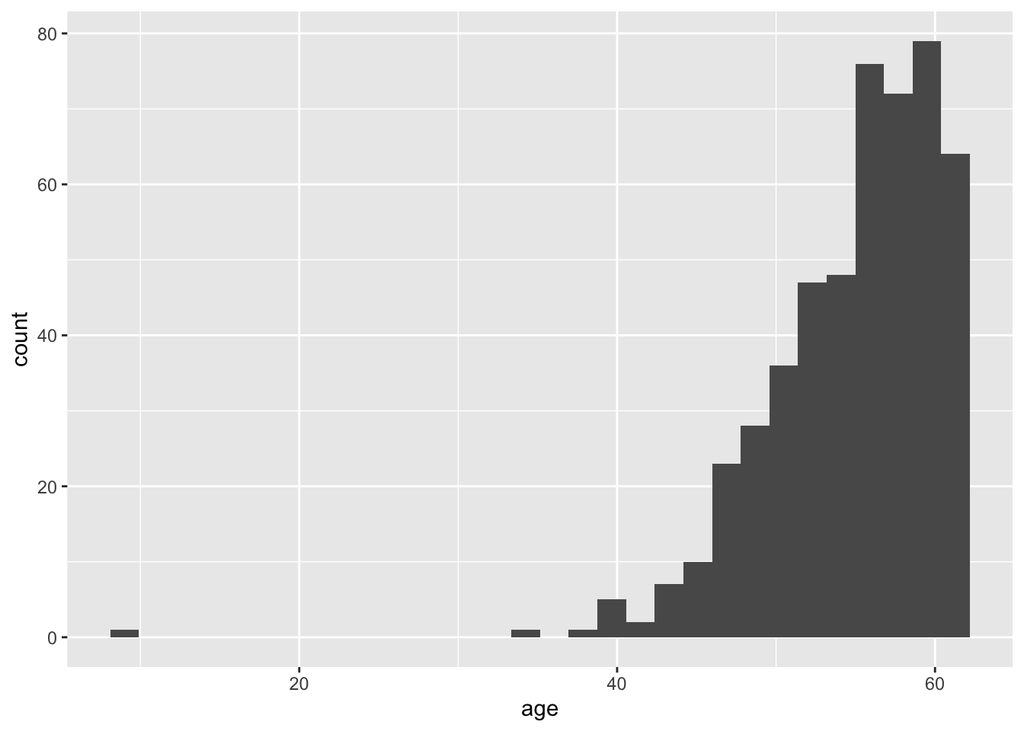

```
ggplot(data, aes(x = work)) +
  geom_histogram()
```

[figure not shown]

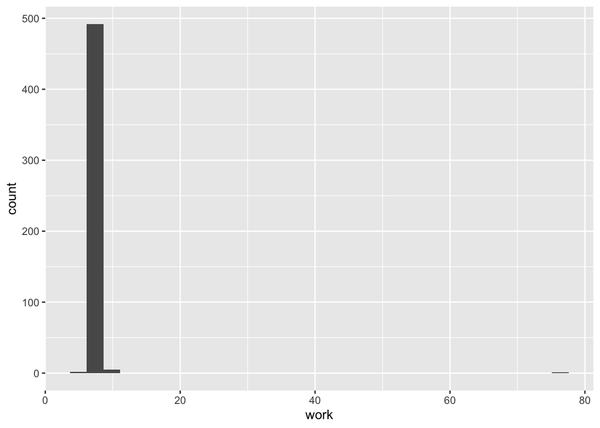

```
ggplot(data, aes(x = age, y = work)) +
  geom_point()
```

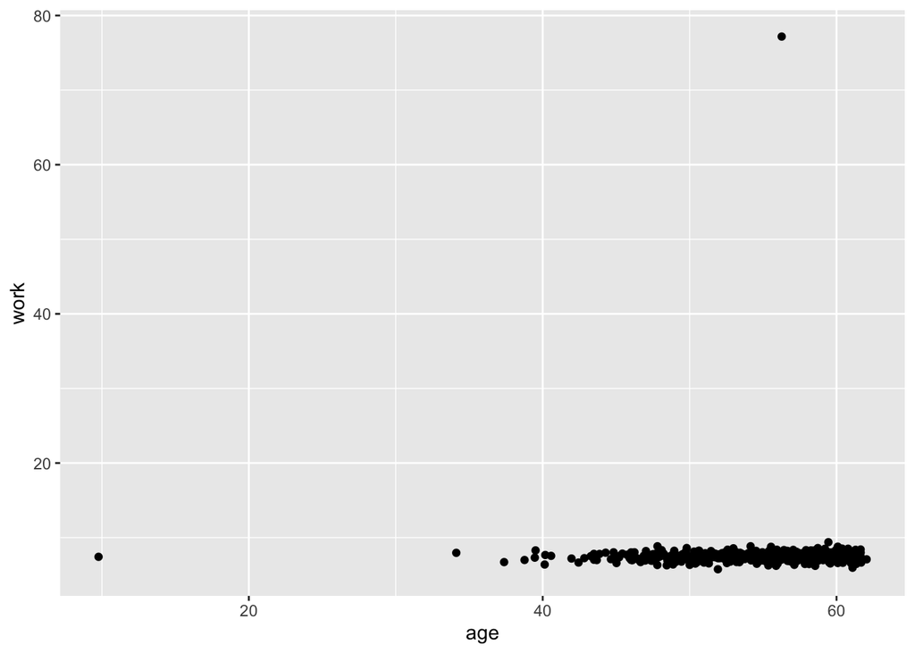

[figure not shown]

# **Task 1**

First, identify the type of each variable in the dataset.

- age is a ‘continuous numerical’ variable
- sex is a ‘binary categorical’ variable
- edu is an ‘ordinal categorical (3 points)’ variable
- work is a ‘continuous numerical’ variable
- meetings is a ‘continuous numerical’ variable
- satisfaction is a ‘categorical ordinal (7 points)’ variable

# **Task 2**

Use the appropriate descriptive indices to identify potential typos and if so, clean the dataset. Use the space below to keep a record of the typos you found.

```
# Summarise data to find typos
summary(data)
```

```
##        id             age             sex              edu
##  Min.   :  1.0   Min.   : 9.771   Male  :299   Bs degree : 27
##  1st Qu.:125.8   1st Qu.:51.986   Female:201   Msc degree: 97
##  Median :250.5   Median :55.943                PhD       :376
##  Mean   :250.5   Mean   :54.876
##  3rd Qu.:375.2   3rd Qu.:59.122
##  Max.   :500.0   Max.   :62.050
##       work           meetings      satisfaction
##  Min.   : 5.761   Min.   :2.660   Min.   : 1.000
##  1st Qu.: 7.146   1st Qu.:2.835   1st Qu.: 4.000
##  Median : 7.458   Median :2.901   Median : 5.000
##  Mean   : 7.609   Mean   :2.901   Mean   : 4.756
##  3rd Qu.: 7.819   3rd Qu.:2.968   3rd Qu.: 6.000
##  Max.   :77.179   Max.   :3.277   Max.   :11.000
```

```
# Remove typos
data$age[data$id==4] <- NA
data$work[data$id==54] <- NA
data$satisfaction[data$id==72] <- NA
```

# **Task 3**

Fill in the blanks to appropriately describe the data (clean dataset).

```
# Summarise data to find typos
summary(data)
```

```
##        id             age            sex              edu           work
##  Min.   :  1.0   Min.   :34.12   Male  :299   Bs degree : 27   Min.   :5.761
##  1st Qu.:125.8   1st Qu.:52.04   Female:201   Msc degree: 97   1st Qu.:7.145
##  Median :250.5   Median :55.94                PhD       :376   Median :7.458
##  Mean   :250.5   Mean   :54.97                                 Mean   :7.470
##  3rd Qu.:375.2   3rd Qu.:59.13                                 3rd Qu.:7.816
##  Max.   :500.0   Max.   :62.05                                 Max.   :9.388
##                  NA's   :1                                     NA's   :1
##     meetings      satisfaction
##  Min.   :2.660   Min.   :1.000
##  1st Qu.:2.835   1st Qu.:4.000
##  Median :2.901   Median :5.000
##  Mean   :2.901   Mean   :4.743
##  3rd Qu.:2.968   3rd Qu.:6.000
##  Max.   :3.277   Max.   :7.000
##                  NA's   :1
```

```
# Standard deviation work
sd(data$work, na.rm = TRUE)
```

```
## [1] 0.5083763
```

```
# Standard deviation meetings
sd(data$meetings, na.rm = TRUE)
```

```
## [1] 0.1023786
```

# **Task 4**

In all universities, the academic staff is expected to work on average 7 hours per day. Does our sample support this null hypothesis?

Print the test value for the population mean and the sample mean: $\mu_0$ = 7.00 and $\bar{X}$ = 7.47. Compute the standard error $se = \sqrt(\frac{sd}{n})$ = 0.51/22.36 = 0.0228.

```
se = sd(data$work, na.rm = TRUE)/sqrt(length(data$work))
se
```

```
## [1] 0.02273528
```

Compute the 95% CI under the null hypothesis.

```
7.00 - 1.96*se
```

```
## [1] 6.955439
```

```
7.00 + 1.96*se
```

```
## [1] 7.044561
```

95% CI: 6.955,7.045

Do we reject the null hypothesis?

Our sampled value is 7.5 and it is not included in the 95% CI, therefore we reject the null hypothesis in favour of the alternative hypothesis.

# **Task 5**

Use the appropriate command to test if the average hours that researchers spend at work is 7 hours. Write the null and the alternative hypotheses and report on the results.

$H_0$: the mean hours of work in our sample equals 7.

$H_\alpha$: the mean hours of work in our sample is different to 7.

```
t.test(data$work,
       mu = 7.00)
```

```
##
##  One Sample t-test
##
## data:  data$work
## t = 20.652, df = 498, p-value < 2.2e-16
## alternative hypothesis: true mean is not equal to 7
## 95 percent confidence interval:
##  7.425289 7.514717
## sample estimates:
## mean of x
##  7.470003
```

In our sample, the mean hours of work was 7.47. This was statistically different to 7 hours (95% CI: 0.425,0.515; t = 20.652, df = 498, p < 0.001). Therefore, we reject the null hypothesis and infer that, on average, researchers work more than 7 hours per day.

## Task 6

Use the appropriate command to test if the average hours that researchers spend at meetings is 2 hours. Write the null and the alternative hypotheses and report on the results.

$H_0$: the mean hours of meetings in our sample equals 2.

$H_\alpha$: the mean hours of meetings in our sample is different to 2.

```
t.test(data$meetings,
       mu = 2.00)
```

```
##
##  One Sample t-test
##
## data:  data$meetings
## t = 196.68, df = 499, p-value < 2.2e-16
## alternative hypothesis: true mean is not equal to 2
## 95 percent confidence interval:
##  2.891523 2.909514
## sample estimates:
## mean of x
##  2.900518
```

In our sample, the average hours of meetings was 2.90. This was significantly different to 2 hours (mean difference=0.901, 95% CI = 0.892,0.910; t=196.684, df=499, p<0.001). Therefore, we reject the null hypothesis and infer that, on average, researchers are in meetings for more than 2 hours per day.

# **Task 7**

Use the appropriate command to test if the proportion of female researchers is equal to that of males. Write the null and the alternative hypotheses and report on the results.

$H_0$: the proportion of females in our sample equals 0.5 (50%).

$H_\alpha$: the proportion of females in our sample is different to 0.5 (50%).

```
chisq.test(table(data$sex))
```

```
##
##  Chi-squared test for given probabilities
##
## data:  table(data$sex)
## X-squared = 19.208, df = 1, p-value = 1.172e-05
```

In our sample, the proportion of females was 40.2%. This was significantly different to 50% ($\chi^2$ = 19.208, df = 1, *p* < 0.001). Therefore, we reject the null hypothesis and infer that the proportion of female researchers is smaller than the proportion of male researchers.